# DigitalCorpsDataTaskCode

# Importing and Merging Data

```r
numeric <- read_csv("Data/data_numeric.csv")
categorical <- read_csv("Data/data_categorical.csv")
```

```
## ──────────────────────────────────────────────────────── Delimiter: "," dbl
## (23): PERSONID, DIABETE3...2, _RACE, MSCODE, FLUSHOT6, EMPLOY1, SEX, MAR...
```

```r
ordinal <- read_csv("Data/data_ordinal.csv")
num_ord <- left_join(numeric, ordinal, "PERSONID")
```

```
## left_join: added 11 columns (DIABETE3.x, DIABETE3.y, GENHLTH, _AGEG5YR, _BMI5CAT, …)
##            > rows only in x       0
##            > rows only in y  (    0)
##            > matched rows     5,000
##            >                 =======
##            > rows total       5,000
```

```r
num_ord_cat <- left_join(num_ord, categorical, "PERSONID")
```

```
## left_join: added 22 columns (DIABETE3...2, _RACE, MSCODE, FLUSHOT6, EMPLOY1, …)
##            > rows only in x       0
##            > rows only in y  (    0)
##            > matched rows     5,000
##            >                 =======
##            > rows total       5,000
```

# Run data quality checks on columns that look to be identical

```r
data1 <- num_ord_cat %>%
  select(starts_with("DIABET") | starts_with("MARITAL")) %>%
  mutate(DIABET3_diff = ifelse(DIABETE3.x == DIABETE3.y &
                                 DIABETE3.x == `DIABETE3...2` &
                                 DIABETE3.x == `DIABETE3...20`, 0, 1)) %>%
  mutate(MARITAL_DIFF = ifelse((`MARITAL...8` == `MARITAL...23`) |
                                 (is.na(`MARITAL...8`) & is.na(`MARITAL...23`)), 0 ,1))
```

```
## select: dropped 32 variables (PERSONID, NUMADULT, CHILDREN, WEIGHT2, DRVISITS, …)
```

```
## mutate: new variable 'DIABET3_diff' (double) with one unique value and 0% NA
```

```
## mutate: new variable 'MARITAL_DIFF' (double) with one unique value and 0% NA
```

# Take out duplicate columns and clean up variable names using janitor

```r
data2 <- num_ord_cat %>%
  select(-c(DIABETE3.y, `DIABETE3...2`, `DIABETE3...20`, `MARITAL...8`)) %>%
  janitor::clean_names()
```

```
## select: dropped 4 variables (DIABETE3.y, DIABETE3...2, MARITAL...8, DIABETE3...20)
```

# Account for NA and 0 values in data as provided by data documentation

```r
data3 <- data2 %>%
  replace_with_na(replace = list(weight2 = c(9999, 7777),
                                 children = 99,
                                 drvisits = c(77, 99),
                                 income2 = c(77, 99),
                                 checkup1 = c(7, 9),
                                 sleptim1 = c(77, 99),
                                 menthlth = c(77, 99),
                                 diabete3_x = c(7, 9),
                                 race = c(6, 9),
                                 flushot6 = c(7, 9),
                                 employ1 = 9,
                                 marital_23 = 9,
                                 cvdcrhd4 = c(7, 9),
                                 hlthcvr1 = c(77, 99),
                                 chckidny = c(7, 9),
                                 useequip = c(7, 9),
                                 totinda = 9,
                                 addepev2 = c(7, 9),
                                 renthom1 = c(7, 9),
                                 exerany2 = c(7, 9),
                                 blind = c(7, 9),
                                 decide = c(7, 9),
                                 hlthpln1 = c(7, 9),
                                 genhlth = c(7, 9),
                                 asthma3 = c(7, 9)))%>%
  mutate(children = replace(children, children == 88, 0)) %>%
  mutate(drvisits = replace(drvisits, drvisits == 88, 0)) %>%
  mutate(menthlth = replace(menthlth, menthlth == 88, 0)) %>%
  mutate(checkup1 = replace(checkup1, checkup1 == 88, 0)) %>%
  mutate(marital = marital_23) %>%
  mutate(diabete3 = diabete3_x) %>%
  select(-c(marital_23, diabete3_x))
```

```
## mutate: changed 3,670 values (73%) of 'children' (0 new NA)
```

```
## mutate: changed 351 values (7%) of 'drvisits' (0 new NA)
```

```
## mutate: changed 3,454 values (69%) of 'menthlth' (0 new NA)
```

```
## mutate: no changes
```

```
## mutate: new variable 'marital' (double) with 7 unique values and 1% NA
```

```
## mutate: new variable 'diabete3' (double) with 5 unique values and <1% NA
```

```
## select: dropped 2 variables (diabete3_x, marital_23)
```

# The documentation specifies that some weight values are in kilograms– convert all of them to pounds

```r
data3_cleanweight1 <- data3 %>%
  mutate(
    weight_correct = case_when(
      nchar(as.character(weight2))==4 ~ as.numeric(str_sub(weight2, -3)) * 2.20462,
      TRUE ~ weight2
    )) %>%
  select(-weight2)
```

```
## mutate: new variable 'weight_correct' (double) with 230 unique values and 5% NA
```

```
## select: dropped one variable (weight2)
```

# The data currently uses state fips codes instead of abbreviations. Abbreviations will make the data and results easier to interpret.

```r
data3_cleanweight1$state <- fips(data3_cleanweight1$state, to="Abbreviation")
```

# Check for unique ID’s

```r
uniqueidcheck <- data3_cleanweight1 %>%
  group_by(personid) %>%
  mutate(duplicate_name = n()-1)
```

```
## group_by: one grouping variable (personid)
```

```
## mutate (grouped): new variable 'duplicate_name' (double) with one unique value and 0% NA
```

```r
# All ID's are unique!
```

# Check missingness of data using vis_dat– sorts columns according to types of data

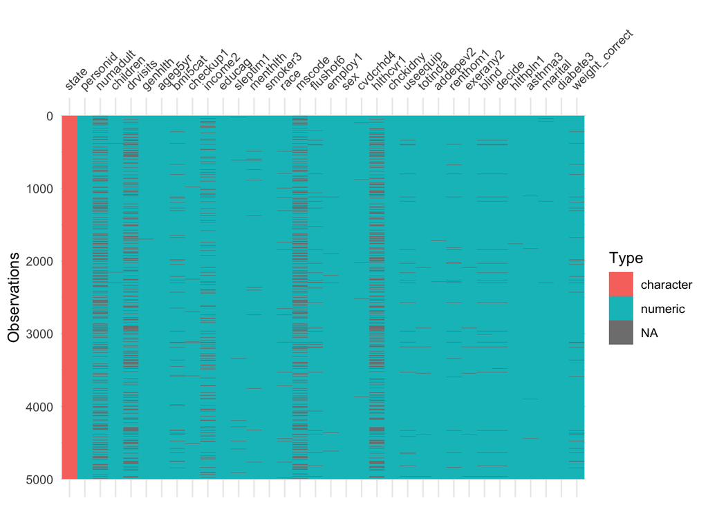

```r
vis_dat(data3_cleanweight1)
```

# Choosing variables based on factors contributing to health outcomes:

## Demographic

##### BMI- bmi5cat

##### Age - ageg5yr

##### Gender - sex

##### Race - race

# Social

##### Stress - menthlth

##### Depression - addepev2

## Lifestyle

##### Smoking - smoker3

##### Physical exercise - totinda

##### Sleep - sleptim1

## Medical history

##### Diagnosed with coronary heart disease or angina - cvdcrhd4

##### Ever told you have kidney disease - chckidny

# Choosing the necessary variables

```r
data4 <- data3_cleanweight1 %>%
  select(personid, ageg5yr, bmi5cat, sex, race,
         addepev2, menthlth, cvdcrhd4, chckidny,
         totinda, smoker3, diabete3, sleptim1) %>%
  filter(ageg5yr > 2) %>%
  filter(diabete3 == 1 | diabete3 == 3) %>%
  mutate(diabete3 = case_when(diabete3 == 3 ~ 0,
         TRUE ~ 1)) %>%
  na.omit()
```

```
## select: dropped 21 variables (numadult, children, drvisits, genhlth, checkup1, …)
```

```
## filter: removed 499 rows (10%), 4,501 rows remaining
```

```
## filter: removed 116 rows (3%), 4,385 rows remaining
```

```
## mutate: changed 3,764 values (86%) of 'diabete3' (0 new NA)
```

# Check racial breakdown of data and assess if it is representative of nation

```r
data4_sample <- data4 %>%
  group_by(race) %>%
  mutate(Freq=n()) %>%
  mutate(perc_total_respondents = Freq/3808) %>%
  # Compare perc_total_respondents with actual national racial breakdown using https://www.census.gov/content/dam/Census/library/publications/2015/demo/p25-1143.pdf page 9
  # There are a disproportionate number of white respondents, which could potentially skew the sample
  # Let's use weights to fix for heteroskedasticity AFTER establishing the training and test models because the representative-ness will change based on the random sample
  ungroup()
```

```
## group_by: one grouping variable (race)
```

```
## mutate (grouped): new variable 'Freq' (integer) with 7 unique values and 0% NA
```

```
## mutate (grouped): new variable 'perc_total_respondents' (double) with 7 unique values and 0% NA
```

```
## ungroup: no grouping variables
```

# The following variables are categorical or ordinal. We need to convert the following objects to factors to represent that.

```r
data4_sample$diabete3 <- as.numeric(data4_sample$diabete3)
data4_sample$race <- factor(data4_sample$race)
data4_sample$sex <- factor(data4_sample$sex)
data4_sample$ageg5yr <- factor(data4_sample$ageg5yr)
data4_sample$bmi5cat <- factor(data4_sample$bmi5cat)
data4_sample$smoker3 <- factor(data4_sample$smoker3)
data4_sample$addepev2 <- factor(data4_sample$addepev2)
data4_sample$cvdcrhd4 <- factor(data4_sample$cvdcrhd4)
data4_sample$chckidny <- factor(data4_sample$chckidny)
data4_sample$totinda <- factor(data4_sample$totinda)
```

# Before we start modeling, let’s check the distribution of diabetes

```r
prop.table(table(data4_sample$diabete3))
# Only ~14% of the data captures individuals diagnosed with diabetes. When we're developing models, this imbalance will skew towards not being diagnosed with diabetes, which could lead to false results because does have enough data to learn about the minority.
```

[output not shown]

# Split the data into training and test sets before adjusting the samples. We use the training data to test and validate the model then treat the test dataset as new data to evaluate how effective the model is. We will adjust the sample in the training data.

```r
train <- data4_sample %>%
  dplyr::sample_frac(0.75)
prop.table(table(train$diabete3))

# Creating test sample-- still need to create a racially representative sample here as well before testing the model we created
test  <- dplyr::anti_join(data4_sample, train, by = 'personid')
prop.table(table(test$diabete3))
```

[output not shown]

# Now that the data is split, we will create samples for both over and under sampled data

```r
# Try oversampling first
data_balanced_over_train <- ovun.sample(diabete3 ~ ., data = train, method = "over")$data
# We replicate the observations from minority class (individuals with diabetes) to balance the data
prop.table(table(data_balanced_over_train$diabete3))

# Now undersampling
data_balanced_under_train <- ovun.sample(diabete3 ~ ., data = train, method = "under")$data
# We reduce the number of observations from majority class (individuals without diabetes) to balance the data
prop.table(table(data_balanced_under_train$diabete3))
```

[output not shown]

# Now that we have the following:

## Clean data

## Training/test sets,

## Non-sampled, Over-sampled, and Under-sampled datasets.

# We can use a logit model to predict if someone will be diagnosed with diabetes. Start with the non-sampled data.

## Run the regression and examine the results

```r
mylogit <- glm(diabete3 ~.-personid, data = train, family = binomial(link = "logit"), )

anova_logit <- anova(mylogit, test="Chisq")
# Use a chi-squared test because we have a lot of categorical and ordinal variables. The p values we have in the regression output correspond to individual Wald tests, but those p values do not tell us if the entire categorical/ordinal variable) explains the probability of getting diabetes. We have to test the coefficients together, so we perform a deviance goodness of fit test.
```

# View regression output

```r
summary(mylogit)
```

```
##
## Call:
## glm(formula = diabete3 ~ . - personid, family = binomial(link = "logit"),
##     data = train)
##
## Deviance Residuals:
##     Min       1Q   Median       3Q      Max
## -1.6974  -0.5501  -0.3642  -0.2005   3.0682
##
## Coefficients: (2 not defined because of singularities)
##                         Estimate Std. Error z value Pr(>|z|)
## (Intercept)            -2.274770   0.833429  -2.729 0.006345 **
## ageg5yr4               -0.429434   0.695361  -0.618 0.536859
## ageg5yr5                0.208875   0.594691   0.351 0.725413
## ageg5yr6                0.677264   0.550665   1.230 0.218734
## ageg5yr7                1.319607   0.508072   2.597 0.009396 **
## ageg5yr8                1.378975   0.500886   2.753 0.005904 **
## ageg5yr9                2.050005   0.491428   4.172 3.03e-05 ***
## ageg5yr10               2.135790   0.490473   4.355 1.33e-05 ***
## ageg5yr11               2.099132   0.502517   4.177 2.95e-05 ***
## ageg5yr12               2.464452   0.506746   4.863 1.15e-06 ***
## ageg5yr13               2.570775   0.502631   5.115 3.14e-07 ***
## ageg5yr14               1.720143   0.919548   1.871 0.061395 .
## bmi5cat2               -0.394215   0.559429  -0.705 0.481013
## bmi5cat3                0.239612   0.551757   0.434 0.664093
## bmi5cat4                1.185060   0.550165   2.154 0.031240 *
## sex2                   -0.236030   0.123480  -1.911 0.055944 .
## race2                   0.835589   0.201108   4.155 3.25e-05 ***
## race3                   0.568521   0.429684   1.323 0.185797
## race4                   0.161885   0.633477   0.256 0.798298
## race5                   2.472778   0.855672   2.890 0.003854 **
## race7                   0.855859   0.407450   2.101 0.035682 *
## race8                   0.553414   0.248305   2.229 0.025830 *
## addepev22              -0.332116   0.155536  -2.135 0.032736 *
## menthlth                0.013407   0.008335   1.608 0.107743
## cvdcrhd42              -0.998036   0.176551  -5.653 1.58e-08 ***
## chckidny2              -0.830491   0.238027  -3.489 0.000485 ***
## totinda2                0.248112   0.129989   1.909 0.056299 .
## smoker32               -0.076374   0.347937  -0.220 0.826257
## smoker33               -0.183634   0.228030  -0.805 0.420642
## smoker34               -0.096136   0.221531  -0.434 0.664315
## smoker39               -0.260391   0.403128  -0.646 0.518327
## sleptim1                0.026544   0.040171   0.661 0.508761
## Freq                          NA         NA      NA       NA
## perc_total_respondents        NA         NA      NA       NA
## ---
## Signif. codes:  0 '***' 0.001 '**' 0.01 '*' 0.05 '.' 0.1 ' ' 1
##
## (Dispersion parameter for binomial family taken to be 1)
##
##     Null deviance: 2333.0  on 2895  degrees of freedom
## Residual deviance: 1939.2  on 2864  degrees of freedom
## AIC: 2003.2
##
## Number of Fisher Scoring iterations: 6
```

```r
anova_logit
```

```
## Analysis of Deviance Table
##
## Model: binomial, link: logit
##
## Response: diabete3
##
## Terms added sequentially (first to last)
##
##
##                        Df Deviance Resid. Df Resid. Dev  Pr(>Chi)
## NULL                                    2895     2333.0
## ageg5yr                11  140.239      2884     2192.8 < 2.2e-16 ***
## bmi5cat                 3  147.218      2881     2045.6 < 2.2e-16 ***
## sex                     1    1.818      2880     2043.8 0.1775382
## race                    6   31.634      2874     2012.1 1.917e-05 ***
## addepev2                1   15.803      2873     1996.3 7.028e-05 ***
## menthlth                1    4.276      2872     1992.0 0.0386488 *
## cvdcrhd4                1   36.405      2871     1955.6 1.603e-09 ***
## chckidny                1   11.447      2870     1944.2 0.0007162 ***
## totinda                 1    3.586      2869     1940.6 0.0582620 .
## smoker3                 4    0.936      2865     1939.7 0.9193378
## sleptim1                1    0.435      2864     1939.2 0.5096573
## Freq                    0    0.000      2864     1939.2
## perc_total_respondents  0    0.000      2864     1939.2
## ---
## Signif. codes:  0 '***' 0.001 '**' 0.01 '*' 0.05 '.' 0.1 ' ' 1
```

```r
# How to interpret this test: rejecting the null means the reduction in deviance is larger than one would expect if a variable did not explain anything about the outcome
```

## Make predictions using test data

```r
probabilities <- mylogit %>% predict(test, type = "response")
# The result is continuous values of probabilities of diabetes occurrence, but we are interested in predicting if someone will have diabetes or not. If anyone has a probability above 50%, we assume that they will be diagnosed with diabetes.
predicted_classes <- ifelse(probabilities > 0.5, 1, 0)
# Take these predictions and append as a column to the test dataframe
# Do do that, we must first converting predicted classes to a dataframe
predicted_classes_logit <- as.data.frame(predicted_classes)
test_predicted_logit <- cbind(predicted_classes_logit, test)
```

## Evaluate the model by creating a confusion matrix

```r
logitconfusionmatrix <-confusionMatrix(data=as.factor(test_predicted_logit$predicted_classes), reference=as.factor(test_predicted_logit$diabete3))
```

```r
logitconfusionmatrix
```

```
## Confusion Matrix and Statistics
##
##           Reference
## Prediction   0   1
##          0 825 115
##          1  11  14
##
##                Accuracy : 0.8694
##                  95% CI : (0.8465, 0.8901)
##     No Information Rate : 0.8663
##     P-Value [Acc > NIR] : 0.4108
##
##                   Kappa : 0.1447
##
##  Mcnemar's Test P-Value : <2e-16
##
##             Sensitivity : 0.9868
##             Specificity : 0.1085
##          Pos Pred Value : 0.8777
##          Neg Pred Value : 0.5600
##              Prevalence : 0.8663
##          Detection Rate : 0.8549
##    Detection Prevalence : 0.9741
##       Balanced Accuracy : 0.5477
##
##        'Positive' Class : 0
##
```

## Create ROC Curve to calculate the performance of the classification model

```r
roc_object <- roc(test$diabete3, probabilities)
```

```r
# Calculate area under curve, the closer this is to 1 the more useful the model is
auc_logit <- auc(roc_object)
auc_logit
```

```
## Area under the curve: 0.8213
```

# Logistic Regression using Oversampled Data

## Run the regression and examine the results

```r
mylogit_oversample <- glm(diabete3 ~.--personid, data = data_balanced_over_train, family = binomial(link = "logit"), )
anova_logit_over <- anova(mylogit_oversample, test="Chisq")
```

# View regression output

```r
summary(mylogit_oversample)
```

```
##
## Call:
## glm(formula = diabete3 ~ . - -personid, family = binomial(link = "logit"),
##     data = data_balanced_over_train)
##
## Deviance Residuals:
##     Min       1Q   Median       3Q      Max
## -2.6305  -0.9421  -0.1744   0.9084   2.3422
##
## Coefficients: (2 not defined because of singularities)
##                          Estimate Std. Error z value Pr(>|z|)
## (Intercept)            -2.225e-01  4.453e-01  -0.500 0.617307
## personid               -5.476e-08  2.470e-07  -0.222 0.824588
## ageg5yr4               -1.046e+00  3.517e-01  -2.974 0.002942 **
## ageg5yr5                2.154e-02  2.787e-01   0.077 0.938395
## ageg5yr6                6.207e-01  2.568e-01   2.417 0.015645 *
## ageg5yr7                1.258e+00  2.390e-01   5.266 1.40e-07 ***
## ageg5yr8                1.259e+00  2.366e-01   5.321 1.03e-07 ***
## ageg5yr9                2.120e+00  2.325e-01   9.119  < 2e-16 ***
## ageg5yr10               2.071e+00  2.326e-01   8.905  < 2e-16 ***
## ageg5yr11               2.052e+00  2.397e-01   8.560  < 2e-16 ***
## ageg5yr12               2.369e+00  2.444e-01   9.693  < 2e-16 ***
## ageg5yr13               2.554e+00  2.404e-01  10.627  < 2e-16 ***
## ageg5yr14               1.606e+00  4.816e-01   3.335 0.000852 ***
## bmi5cat2               -4.678e-01  2.907e-01  -1.609 0.107520
## bmi5cat3                2.042e-01  2.878e-01   0.709 0.478042
## bmi5cat4                1.141e+00  2.894e-01   3.941 8.10e-05 ***
## sex2                   -2.676e-01  6.952e-02  -3.849 0.000119 ***
## race2                   8.859e-01  1.215e-01   7.290 3.11e-13 ***
## race3                   5.196e-01  2.605e-01   1.995 0.046086 *
## race4                   2.994e-01  3.067e-01   0.976 0.328848
## race5                   2.057e+00  5.736e-01   3.585 0.000337 ***
## race7                   1.352e+00  2.355e-01   5.739 9.52e-09 ***
## race8                   4.686e-01  1.483e-01   3.161 0.001575 **
## addepev22              -3.275e-01  9.022e-02  -3.631 0.000283 ***
## menthlth                1.366e-02  4.942e-03   2.764 0.005701 **
## cvdcrhd42              -8.725e-01  1.180e-01  -7.394 1.42e-13 ***
## chckidny2              -8.937e-01  1.614e-01  -5.539 3.04e-08 ***
## totinda2                2.780e-01  7.533e-02   3.690 0.000224 ***
## smoker32               -2.528e-01  1.960e-01  -1.290 0.197092
## smoker33               -3.842e-01  1.295e-01  -2.967 0.003004 **
## smoker34               -3.168e-01  1.244e-01  -2.545 0.010916 *
## smoker39               -4.949e-01  2.292e-01  -2.159 0.030873 *
## sleptim1                2.769e-02  2.243e-02   1.234 0.217022
## Freq                           NA         NA      NA       NA
## perc_total_respondents         NA         NA      NA       NA
## ---
## Signif. codes:  0 '***' 0.001 '**' 0.01 '*' 0.05 '.' 0.1 ' ' 1
##
## (Dispersion parameter for binomial family taken to be 1)
##
##     Null deviance: 6857.7  on 4946  degrees of freedom
## Residual deviance: 5482.9  on 4914  degrees of freedom
## AIC: 5548.9
##
## Number of Fisher Scoring iterations: 5
```

```r
anova_logit_over
```

```
## Analysis of Deviance Table
##
## Model: binomial, link: logit
##
## Response: diabete3
##
## Terms added sequentially (first to last)
##
##
##                        Df Deviance Resid. Df Resid. Dev  Pr(>Chi)
## NULL                                    4946     6857.7
## personid                1     0.58      4945     6857.1 0.4471513
## ageg5yr                11   570.09      4934     6287.0 < 2.2e-16 ***
## bmi5cat                 3   471.94      4931     5815.0 < 2.2e-16 ***
## sex                     1     8.15      4930     5806.9 0.0043142 **
## race                    6   113.76      4924     5693.1 < 2.2e-16 ***
## addepev2                1    52.58      4923     5640.6 4.129e-13 ***
## menthlth                1    16.10      4922     5624.5 5.998e-05 ***
## cvdcrhd4                1    82.57      4921     5541.9 < 2.2e-16 ***
## chckidny                1    33.89      4920     5508.0 5.832e-09 ***
## totinda                 1    14.04      4919     5494.0 0.0001794 ***
## smoker3                 4     9.55      4915     5484.4 0.0486979 *
## sleptim1                1     1.53      4914     5482.9 0.2162917
## Freq                    0     0.00      4914     5482.9
## perc_total_respondents  0     0.00      4914     5482.9
## ---
## Signif. codes:  0 '***' 0.001 '**' 0.01 '*' 0.05 '.' 0.1 ' ' 1
```

## Make predictions using test data

```r
probabilities_logit_over <- mylogit_oversample %>% predict(test, type = "response")
predicted_classes_over <- ifelse(probabilities_logit_over > 0.5, 1, 0)
# Take these and append as columns to the test dataframe
predicted_classes_logit_over <- as.data.frame(predicted_classes_over)
test_predicted_logit_over <- cbind(predicted_classes_logit_over, test)
```

## Evaluate the model by creating a confusion matrix

```r
logitconfusionmatrix_over <- confusionMatrix(data=as.factor(test_predicted_logit_over$predicted_classes_over), reference=as.factor(test_predicted_logit_over$diabete3))
```

```r
logitconfusionmatrix_over
```

```
## Confusion Matrix and Statistics
##
##           Reference
## Prediction   0   1
##          0 594  27
##          1 242 102
##
##                Accuracy : 0.7212
##                  95% CI : (0.6918, 0.7493)
##     No Information Rate : 0.8663
##     P-Value [Acc > NIR] : 1
##
##                   Kappa : 0.294
##
##  Mcnemar's Test P-Value : <2e-16
##
##             Sensitivity : 0.7105
##             Specificity : 0.7907
##          Pos Pred Value : 0.9565
##          Neg Pred Value : 0.2965
##              Prevalence : 0.8663
##          Detection Rate : 0.6155
##    Detection Prevalence : 0.6435
##       Balanced Accuracy : 0.7506
##
##        'Positive' Class : 0
##
```

## Create ROC Curve to calculate the performance of the classification model

```r
roc_object_over <- roc(test$diabete3, probabilities_logit_over)
```

```r
# calculate area under curve
auc_logit_over <- auc(roc_object)
auc_logit_over
```

```
## Area under the curve: 0.8213
```

# Logistic Regression using Undersampled Data

## Run the regression and examine the results

```r
mylogit_undersample <- glm(diabete3 ~.-personid, data = data_balanced_under_train, family = binomial(link = "logit"), )
anova_logit_under <- anova(mylogit_undersample, test="Chisq")
```

# View regression output

```r
summary(mylogit_undersample)
```

```
##
## Call:
## glm(formula = diabete3 ~ . - personid, family = binomial(link = "logit"),
##     data = data_balanced_under_train)
##
## Deviance Residuals:
##     Min       1Q   Median       3Q      Max
## -2.2039  -0.9434  -0.2477   0.9501   2.3140
##
## Coefficients: (2 not defined because of singularities)
##                          Estimate Std. Error z value Pr(>|z|)
## (Intercept)               0.03986    1.10666   0.036 0.971269
## ageg5yr4                 -1.25542    0.78292  -1.604 0.108822
## ageg5yr5                 -0.13393    0.70522  -0.190 0.849374
## ageg5yr6                  0.29689    0.65562   0.453 0.650665
## ageg5yr7                  0.99274    0.61202   1.622 0.104790
## ageg5yr8                  0.90194    0.60144   1.500 0.133706
## ageg5yr9                  1.90546    0.59869   3.183 0.001459 **
## ageg5yr10                 1.75184    0.59284   2.955 0.003127 **
## ageg5yr11                 1.75877    0.60505   2.907 0.003652 **
## ageg5yr12                 2.04527    0.61846   3.307 0.000943 ***
## ageg5yr13                 2.45160    0.61650   3.977 6.99e-05 ***
## ageg5yr14                17.02053 1028.50290   0.017 0.986797
## bmi5cat2                 -0.71190    0.74536  -0.955 0.339523
## bmi5cat3                 -0.14214    0.73412  -0.194 0.846471
## bmi5cat4                  0.74755    0.73690   1.014 0.310367
## sex2                     -0.21143    0.17166  -1.232 0.218069
## race2                     0.61499    0.27961   2.199 0.027846 *
## race3                     1.12643    0.65981   1.707 0.087783 .
## race4                     0.32088    0.76304   0.421 0.674095
## race5                    15.94163  743.86853   0.021 0.982902
## race7                     1.08857    0.59132   1.841 0.065633 .
## race8                     0.95048    0.39160   2.427 0.015216 *
## addepev22                -0.37799    0.22526  -1.678 0.093334 .
## menthlth                  0.01065    0.01171   0.909 0.363384
## cvdcrhd42                -0.86101    0.28230  -3.050 0.002289 **
## chckidny2                -0.59924    0.36019  -1.664 0.096178 .
## totinda2                  0.14047    0.18558   0.757 0.449080
## smoker32                 -0.61603    0.45922  -1.341 0.179769
## smoker33                 -0.39930    0.32935  -1.212 0.225357
## smoker34                 -0.56240    0.31602  -1.780 0.075136 .
## smoker39                 -0.25851    0.59028  -0.438 0.661425
## sleptim1                  0.05266    0.05204   1.012 0.311591
## Freq                           NA         NA      NA       NA
## perc_total_respondents         NA         NA      NA       NA
## ---
## Signif. codes:  0 '***' 0.001 '**' 0.01 '*' 0.05 '.' 0.1 ' ' 1
##
## (Dispersion parameter for binomial family taken to be 1)
##
##     Null deviance: 1144.49  on 825  degrees of freedom
## Residual deviance:  917.93  on 794  degrees of freedom
## AIC: 981.93
##
## Number of Fisher Scoring iterations: 14
```

```r
anova_logit_under
```

```
## Analysis of Deviance Table
##
## Model: binomial, link: logit
##
## Response: diabete3
##
## Terms added sequentially (first to last)
##
##
##                        Df Deviance Resid. Df Resid. Dev  Pr(>Chi)
## NULL                                     825    1144.49
## ageg5yr                11  103.722       814    1040.77 < 2.2e-16 ***
## bmi5cat                 3   64.966       811     975.80   5.1e-14 ***
## sex                     1    0.590       810     975.21 0.4423447
## race                    6   23.352       804     951.86 0.0006866 ***
## addepev2                1    9.641       803     942.22 0.0019026 **
## menthlth                1    1.589       802     940.63 0.2074349
## cvdcrhd4                1   14.160       801     926.47 0.0001679 ***
## chckidny                1    2.896       800     923.58 0.0888081 .
## totinda                 1    0.798       799     922.78 0.3717716
## smoker3                 4    3.820       795     918.96 0.4308533
## sleptim1                1    1.029       794     917.93 0.3103758
## Freq                    0    0.000       794     917.93
## perc_total_respondents  0    0.000       794     917.93
## ---
## Signif. codes:  0 '***' 0.001 '**' 0.01 '*' 0.05 '.' 0.1 ' ' 1
```

## Make predictions using test data

```r
probabilities_logit_under <- mylogit_undersample %>% predict(test, type = "response")
predicted_classes_under <- ifelse(probabilities_logit_under > 0.5, 1, 0)
# Take these and append as columns to the test dataframe
predicted_classes_logit_under <- as.data.frame(predicted_classes_under)
test_predicted_logit_under <- cbind(predicted_classes_logit_under, test)
```

## Evaluate the model by creating a confusion matrix

```r
logitconfusionmatrix_under <- confusionMatrix(data=as.factor(test_predicted_logit_under$predicted_classes_under),                                  reference=as.factor(test_predicted_logit_under$diabete3))
```

```r
logitconfusionmatrix_under
```

```
## Confusion Matrix and Statistics
##
##           Reference
## Prediction   0   1
##          0 597  30
##          1 239  99
##
##                Accuracy : 0.7212
##                  95% CI : (0.6918, 0.7493)
##     No Information Rate : 0.8663
##     P-Value [Acc > NIR] : 1
##
##                   Kappa : 0.2858
##
##  Mcnemar's Test P-Value : <2e-16
##
##             Sensitivity : 0.7141
##             Specificity : 0.7674
##          Pos Pred Value : 0.9522
##          Neg Pred Value : 0.2929
##              Prevalence : 0.8663
##          Detection Rate : 0.6187
##    Detection Prevalence : 0.6497
##       Balanced Accuracy : 0.7408
##
##        'Positive' Class : 0
##
```

## Create ROC Curve to calculate the performance of the classification model

```r
roc_object_under <- roc(test$diabete3, probabilities_logit_under)
```

```r
# calculate area under curve
auc_logit_under <- auc(roc_object)
auc_logit_under
```

```
## Area under the curve: 0.8213
```

## Cons of this approach

###### Given the time constraints, I chose regressors based on commonly cited empirical literature. If I had more time, I would try variations of this model with different regressors or use Mallows CP and compare confusion matrices and AUC’s to see which factors are most significant.